# GIS Coursework - Spatially analysing the Trump effect

## Analysing Hate Crime following the Trump election

**Libraries**

```r
library(sf)
library(dplyr)
library(tmap)
library(readxl)
library(plyr)
library(spdep)
library(RColorBrewer)
```

Read in the election results CSV and check that it has worked properly

```r
elections <- read.csv("1976-2016-president.csv",
                      header = TRUE, sep = ",")
head(elections)
```

```
##   year   state state_po state_fips state_cen state_ic       office
## 1 1976 Alabama       AL          1        63       41 US President
## 2 1976 Alabama       AL          1        63       41 US President
## 3 1976 Alabama       AL          1        63       41 US President
## 4 1976 Alabama       AL          1        63       41 US President
## 5 1976 Alabama       AL          1        63       41 US President
## 6 1976 Alabama       AL          1        63       41 US President
##                 candidate                      party writein
## 1           Carter, Jimmy                   democrat   FALSE
## 2            Ford, Gerald                 republican   FALSE
## 3          Maddox, Lester american independent party   FALSE
## 4 Bubar, Benjamin ""Ben""                prohibition   FALSE
## 5               Hall, Gus        communist party use   FALSE
## 6         Macbride, Roger                libertarian   FALSE
##   candidatevotes totalvotes  version notes
## 1         659170    1182850 20171015    NA
## 2         504070    1182850 20171015    NA
## 3           9198    1182850 20171015    NA
## 4           6669    1182850 20171015    NA
## 5           1954    1182850 20171015    NA
## 6           1481    1182850 20171015    NA
```

```r
class(elections)
```

```
## [1] "data.frame"
```

Check columns have been read in correctly

```r
datatypelist <- data.frame(cbind(lapply(elections,class)))
datatypelist
```

```
##                cbind.lapply.elections..class..
## year                                   integer
## state                                   factor
## state_po                                factor
## state_fips                             integer
## state_cen                              integer
## state_ic                               integer
## office                                  factor
## candidate                               factor
## party                                   factor
## writein                                logical
## candidatevotes                         integer
## totalvotes                             integer
## version                                integer
## notes                                  logical
```

Get all elections for 2016 and check it

```r
elections2016 <- elections [grep("2016",elections[,1]),]

head(elections2016)
```

```
##      year   state state_po state_fips state_cen state_ic       office
## 3396 2016 Alabama       AL          1        63       41 US President
## 3397 2016 Alabama       AL          1        63       41 US President
## 3398 2016 Alabama       AL          1        63       41 US President
## 3399 2016 Alabama       AL          1        63       41 US President
## 3400 2016 Alabama       AL          1        63       41 US President
## 3401 2016  Alaska       AK          2        94       81 US President
##             candidate       party writein candidatevotes totalvotes
## 3396 Trump, Donald J.  republican   FALSE        1318255    2123372
## 3397 Clinton, Hillary    democrat   FALSE         729547    2123372
## 3398    Johnson, Gary libertarian   FALSE          44467    2123372
## 3399                                 TRUE          21712    2123372
## 3400      Stein, Jill       green   FALSE           9391    2123372
## 3401 Trump, Donald J.  republican   FALSE         163387     318608
##       version notes
## 3396 20171015    NA
## 3397 20171015    NA
## 3398 20171015    NA
## 3399 20171015    NA
## 3400 20171015    NA
## 3401 20171015    NA
```

```r
nrow(elections2016)
```

```
## [1] 345
```

Still have multiple entries per state so need to group just the Trump votes

```r
trumpvotes <- elections2016 %>% group_by(state) %>% filter(candidate=="Trump, Donald J.")

head(trumpvotes)
```

```
## # A tibble: 6 x 14
## # Groups:   state [6]
##    year state state_po state_fips state_cen state_ic office candidate party
##   <int> <fct> <fct>         <int>     <int>    <int> <fct>  <fct>     <fct>
## 1  2016 Alab~ AL                1        63       41 US Pr~ Trump, D~ repu~
## 2  2016 Alas~ AK                2        94       81 US Pr~ Trump, D~ repu~
## 3  2016 Ariz~ AZ                4        86       61 US Pr~ Trump, D~ repu~
## 4  2016 Arka~ AR                5        71       42 US Pr~ Trump, D~ repu~
## 5  2016 Cali~ CA                6        93       71 US Pr~ Trump, D~ repu~
## 6  2016 Colo~ CO                8        84       62 US Pr~ Trump, D~ repu~
## # ... with 5 more variables: writein <lgl>, candidatevotes <int>,
## #   totalvotes <int>, version <int>, notes <lgl>
```

```r
colnames(trumpvotes)
```

```
##  [1] "year"           "state"          "state_po"       "state_fips"
##  [5] "state_cen"      "state_ic"       "office"         "candidate"
##  [9] "party"          "writein"        "candidatevotes" "totalvotes"
## [13] "version"        "notes"
```

Create a new column for the percent of votes Trump received from each state, to account for the difference in population sizes in different states. And provide checks.

```r
trumpvotes$percenttrump <-  trumpvotes$candidatevotes/trumpvotes$totalvotes*100

colnames(trumpvotes)
```

```
##  [1] "year"           "state"          "state_po"       "state_fips"
##  [5] "state_cen"      "state_ic"       "office"         "candidate"
##  [9] "party"          "writein"        "candidatevotes" "totalvotes"
## [13] "version"        "notes"          "percenttrump"
```

```r
trumpvotes$percenttrump
```

```
##  [1] 62.083092364 51.281512078 48.671616472 60.574102164 31.617106538
##  [6] 43.251397371 40.926914379 41.922824339  4.070383108 49.021941417
## [11] 50.771326055 29.439707173 59.261432369 38.761753074 56.940033448
## [16] 51.162061345 56.654581806 62.519638552 58.088684654 43.476678084
## [21] 33.909304729  0.009311703 32.286202791 47.497564220 44.925193104
## [26] 57.941038089 56.772347838 56.466191869 58.747351127 45.500695318
## [31] 46.458666982 41.350386650 40.042514333 32.390602306  3.747614099
## [36] 49.828094696 62.955627831 51.687650676 65.322864820 39.094035184
## [41] 48.577885804 38.898057499 54.939332686 61.530750379 60.722033694
## [46] 52.234685579 45.540816588 29.759382401 44.427647014 36.832680187
## [51] 68.630574812 47.218184567 67.398411055
```

```r
class(trumpvotes)
```

```
## [1] "grouped_df" "tbl_df"     "tbl"        "data.frame"
```

Read in the shapefile for the U.S AND check projection

```r
States <- st_read("states_21basic/states.shp")
States
```

```
## Simple feature collection with 51 features and 5 fields
## geometry type:  MULTIPOLYGON
## dimension:      XY
## bbox:           xmin: -178.2176 ymin: 18.92179 xmax: -66.96927 ymax: 71.40624
## epsg (SRID):    4269
## proj4string:    +proj=longlat +datum=NAD83 +no_defs
## First 10 features:
##      STATE_NAME DRAWSEQ STATE_FIPS         SUB_REGION STATE_ABBR
## 1        Hawaii       1         15            Pacific         HI
## 2    Washington       2         53            Pacific         WA
## 3       Montana       3         30           Mountain         MT
## 4         Maine       4         23        New England         ME
## 5  North Dakota       5         38 West North Central         ND
## 6  South Dakota       6         46 West North Central         SD
## 7       Wyoming       7         56           Mountain         WY
## 8     Wisconsin       8         55 East North Central         WI
## 9         Idaho       9         16           Mountain         ID
## 10      Vermont      10         50        New England         VT
##                          geometry
## 1  MULTIPOLYGON (((-160.0738 2...
## 2  MULTIPOLYGON (((-122.402 48...
## 3  MULTIPOLYGON (((-111.4754 4...
## 4  MULTIPOLYGON (((-69.77728 4...
## 5  MULTIPOLYGON (((-98.73044 4...
## 6  MULTIPOLYGON (((-102.7884 4...
## 7  MULTIPOLYGON (((-104.0536 4...
## 8  MULTIPOLYGON (((-87.74856 4...
## 9  MULTIPOLYGON (((-117.0263 4...
## 10 MULTIPOLYGON (((-73.25806 4...
```

Current projection is one that I do not know, so project into WGS84 (preferred CRS)

```r
statesWGS84 <- st_transform(States, 4326)

statesWGS84
```

```
## Simple feature collection with 51 features and 5 fields
## geometry type:  MULTIPOLYGON
## dimension:      XY
## bbox:           xmin: -178.2176 ymin: 18.92179 xmax: -66.96927 ymax: 71.40624
## epsg (SRID):    4326
## proj4string:    +proj=longlat +datum=WGS84 +no_defs
## First 10 features:
##      STATE_NAME DRAWSEQ STATE_FIPS         SUB_REGION STATE_ABBR
## 1        Hawaii       1         15            Pacific         HI
## 2    Washington       2         53            Pacific         WA
## 3       Montana       3         30           Mountain         MT
## 4         Maine       4         23        New England         ME
## 5  North Dakota       5         38 West North Central         ND
## 6  South Dakota       6         46 West North Central         SD
## 7       Wyoming       7         56           Mountain         WY
## 8     Wisconsin       8         55 East North Central         WI
## 9         Idaho       9         16           Mountain         ID
## 10      Vermont      10         50        New England         VT
##                          geometry
## 1  MULTIPOLYGON (((-160.0738 2...
## 2  MULTIPOLYGON (((-122.402 48...
## 3  MULTIPOLYGON (((-111.4754 4...
## 4  MULTIPOLYGON (((-69.77728 4...
## 5  MULTIPOLYGON (((-98.73044 4...
## 6  MULTIPOLYGON (((-102.7884 4...
## 7  MULTIPOLYGON (((-104.0536 4...
## 8  MULTIPOLYGON (((-87.74856 4...
## 9  MULTIPOLYGON (((-117.0263 4...
## 10 MULTIPOLYGON (((-73.25806 4...
```

Check it’s all working with a quick map.

```r
tmap_mode("view")
```

```
## tmap mode set to interactive viewing
```

```r
qtm(statesWGS84)
```

[interactive chart not shown]

Join the voting results to the states shapefile

```r
colnames(statesWGS84)
```

```
## [1] "STATE_NAME" "DRAWSEQ"    "STATE_FIPS" "SUB_REGION" "STATE_ABBR"
## [6] "geometry"
```

```r
colnames(trumpvotes)
```

```
##  [1] "year"           "state"          "state_po"       "state_fips"
##  [5] "state_cen"      "state_ic"       "office"         "candidate"
##  [9] "party"          "writein"        "candidatevotes" "totalvotes"
## [13] "version"        "notes"          "percenttrump"
```

```r
trumpmap2016 <- merge(statesWGS84,
                      trumpvotes,
                      by.x="STATE_NAME",
                      by.y="state",
                      no.dups= TRUE)
```

Check that it is all working through a quick map

```r
nrow(trumpmap2016)
```

```
## [1] 53
```

```r
class(trumpmap2016)
```

```
## [1] "sf"         "data.frame"
```

```r
tmap_mode("view")
```

```
## tmap mode set to interactive viewing
```

```r
tm_shape(trumpmap2016) +
  tm_polygons("percenttrump",
              style="cont",
              midpoint=NA,
              title="% vote for trump")
```

[interactive chart not shown]

Add in the hate crime statistics and check

```r
hatecrime2014 <- read_excel("table_12-hatecrime2014.xls", skip=2)
hatecrime2015 <- read_excel("table_12-hatecrime2015.xls", skip=2)
hatecrime2016 <- read_excel("table_12-hatecrime2016.xls", skip=2)
hatecrime2017 <- read_excel("table_12-hatecrime2017.xls", skip=2)
hatecrime2018 <- read_excel("table_12-hatecrime2018.xls", skip=2)

colnames(hatecrime2014)
```

```
## [1] "Participating state"
## [2] "Number of\nparticipating\nagencies"
## [3] "Population\ncovered"
## [4] "Agencies\nsubmitting\nincident\nreports"
## [5] "Total\nnumber of\nincidents\nreported"
```

```r
class(hatecrime2014)
```

```
## [1] "tbl_df"     "tbl"        "data.frame"
```

Add the year to the end of each column name in each data set so that when they become joined, you can clearly keep track of which figures are for which year.

```r
colnames(hatecrime2014) <- paste(colnames(hatecrime2014), "2014", sep = "_")
colnames(hatecrime2015) <- paste(colnames(hatecrime2015), "2015", sep = "_")
colnames(hatecrime2016) <- paste(colnames(hatecrime2016), "2016", sep = "_")
colnames(hatecrime2017) <- paste(colnames(hatecrime2017), "2017", sep = "_")
colnames(hatecrime2018) <- paste(colnames(hatecrime2018), "2018", sep = "_")
```

Rename the first column in each to enable joins. Check results

```r
names(hatecrime2014)[1] <- c("State")
names(hatecrime2015)[1] <- c("State")
names(hatecrime2016)[1] <- c("State")
names(hatecrime2017)[1] <- c("State")
names(hatecrime2018)[1] <- c("State")

colnames(hatecrime2014)
```

```
## [1] "State"
## [2] "Number of\nparticipating\nagencies_2014"
## [3] "Population\ncovered_2014"
## [4] "Agencies\nsubmitting\nincident\nreports_2014"
## [5] "Total\nnumber of\nincidents\nreported_2014"
```

Join all hate crime statistics together

```r
hatecrime <- join_all(list(hatecrime2014,hatecrime2015,hatecrime2016,hatecrime2017,hatecrime2018),
                      by='State', type='left')

class(hatecrime)
```

```
## [1] "data.frame"
```

```r
head(hatecrime)
```

```
##        State Number of\nparticipating\nagencies_2014
## 1      Total                                   15494
## 2    Alabama                                      39
## 3     Alaska                                      33
## 4    Arizona                                      99
## 5   Arkansas                                     270
## 6 California                                     743
##   Population\ncovered_2014 Agencies\nsubmitting\nincident\nreports_2014
## 1                297926030                                         1666
## 2                   794907                                            4
## 3                   732371                                            1
## 4                  6433584                                           22
## 5                  2661818                                            5
## 6                 38802500                                          208
##   Total\nnumber of\nincidents\nreported_2014
```

[output cut: 90 more lines]

Join hate crime to the Trump vote map and check it

```r
trumpmap2016andCrime <- merge(trumpmap2016,
                         hatecrime,
                         by.x="STATE_NAME",
                         by.y="State",
                         no.dups= TRUE)

colnames(trumpmap2016andCrime)
```

```
##  [1] "STATE_NAME"
##  [2] "DRAWSEQ"
##  [3] "STATE_FIPS"
##  [4] "SUB_REGION"
##  [5] "STATE_ABBR"
##  [6] "year"
##  [7] "state_po"
##  [8] "state_fips"
##  [9] "state_cen"
## [10] "state_ic"
## [11] "office"
## [12] "candidate"
## [13] "party"
## [14] "writein"
## [15] "candidatevotes"
```

[output cut: 25 more lines]

Quick map check to see that it’s all working

```r
tmap_mode("view")
```

```
## tmap mode set to interactive viewing
```

```r
tm_shape(trumpmap2016andCrime) +
  tm_polygons("Total\nnumber of\nincidents\nreported_2014")
```

[interactive chart not shown]

## Spatial Analysis

Remove Alaska and Hawaii. As well as rename the columns to make them easier to work with (no spaces)

```r
trumpmap2016andCrime_noH<- subset(trumpmap2016andCrime, STATE_NAME!="Hawaii")
trumpmap2016andCrime_noAorH <- subset(trumpmap2016andCrime_noH, STATE_NAME!="Alaska")

trumpmap2016andCrime_noAorH <- trumpmap2016andCrime_noAorH %>% dplyr::rename_all(list(~make.names(.)))
```

Next you need to standardise the incidents of hate crime across the states. This was done by calculating the number of incidents per 100,000 people in each state.

```r
#values for 2014

trumpmap2016andCrime_noAorH$incident2014per100k <- trumpmap2016andCrime_noAorH$Total.number.of.incidents.reported_2014/trumpmap2016andCrime_noAorH$Population.covered_2014*100000

trumpmap2016andCrime_noAorH$incident2014per100k
```

```
##  [1]  1.13220792  4.11901049  0.30054647  1.95605953  1.82211870
##  [6]  3.64372973  1.38946189 10.62387975  0.32837771  0.49971632
## [11]  1.52997746  0.90609694  0.82053652  0.36979712  2.56754851
## [16]  3.71591616  0.33257519  2.10512229  0.26771938  0.26771938
## [21]  5.78170769  3.19550205  1.85355480  0.07409301  1.25383451
## [26]  3.02205496  2.66542960  0.84671526  1.13068269  3.75982296
## [31]  1.81308489  2.77320115  2.77320115  1.40804642  5.41876192
## [36]  4.14983179  0.85094291  1.70328958  0.39722521  0.37945984
## [41]  1.01805743  2.31814178  2.97550074  0.53857781  1.70858918
## [46]  2.39499542  1.41742712  4.36771138  1.57748038  0.90905688
## [51]  0.00000000
```

```r
#values for 2015

trumpmap2016andCrime_noAorH$incident2015per100k <- trumpmap2016andCrime_noAorH$Total.number.of.incidents.reported_2015/trumpmap2016andCrime_noAorH$Population.covered_2015*100000

trumpmap2016andCrime_noAorH$incident2015per100k
```

```
##  [1] 0.7986289 4.1673713 0.1815183 2.1386234 1.9647978 2.7360441 1.1628718
##  [8] 9.6693384 1.3440667 0.5506033 2.0550326 0.7199419 1.9536368 0.1932309
## [15] 2.2616817 4.2704290 1.0237554 2.8585872 0.6826051 0.6826051 6.2592528
## [22] 3.1420736 2.0887488 0.0000000 1.6448767 4.3953597 1.0432705 2.0063338
## [29] 1.0254671 3.6845182 2.2609797 2.5295525 2.5295525 1.6033158 4.7560729
## [36] 4.2528495 0.9494519 3.8889181 0.5099366 1.7040646 1.1396033 2.0456382
## [43] 3.3483332 0.6973262 1.5842086 1.2778695 1.8853790 3.8389356 2.7433869
## [50] 0.7705055 0.3542475
```

```r
#values for 2016

trumpmap2016andCrime_noAorH$incident2016per100k <- trumpmap2016andCrime_noAorH$Total.number.of.incidents.reported_2016/trumpmap2016andCrime_noAorH$Population.covered_2016*100000

trumpmap2016andCrime_noAorH$incident2016per100k
```

```
##  [1]  1.3808899  3.3480511  0.4205148  2.3724198  1.8841365  2.9638312
##  [7]  1.5755227 16.8827165  1.0680795  0.4746756  1.6041446  0.8970813
## [13]  2.7134399  0.5459592  1.8909150  4.6527070  0.7302446  3.0041781
## [19]  0.6149809  0.6149809  5.8906692  4.0517034  2.2977475  1.1956533
## [25]  1.4450257  1.9192974  1.6787373  1.3945303  2.1957857  3.1533547
## [31]  4.5063939  3.0143692  3.0143692  1.4587551  1.0561154  4.6169344
## [37]  0.8529126  2.9313032  0.4824281  1.1359054  0.4658735  2.2861875
## [43]  2.1349550  0.6388493  2.1896430  4.0026001  1.4504084  5.3143967
## [49]  2.5287319  0.6014739         NA
```

```r
#values for 2017

trumpmap2016andCrime_noAorH$incident2017per100k <- trumpmap2016andCrime_noAorH$Total.number.of.incidents.reported_2017/trumpmap2016andCrime_noAorH$Population.covered_2017*100000

trumpmap2016andCrime_noAorH$incident2017per100k
```

```
##  [1]  0.3083962  3.9077562  0.2468056  2.7675783  1.9011308  3.0934868
##  [7]  3.0147442 27.8109203  0.7067884  0.3017430  3.1190066  0.6682839
## [13]  2.4045839  0.3542971  2.8617380  8.5053932  0.6905839  2.3953763
## [19]  0.7931030  0.7931030  6.3700729  4.5926441  2.6504421  0.1466177
## [25]  1.7186079  1.4285646  2.4117759  0.1667757  1.0034302  5.4965531
## [31]  1.2469383  2.8040766  2.8040766  1.6160803  1.9877976  3.9159578
## [37]  0.9448149  3.7411637  0.6126979  1.0380894  1.7412077  2.1274386
## [43]  2.0250197  0.6762313  2.5520838  5.4517146  2.2792375  6.8954645
## [49]  1.9483891  0.7976093  0.7231325
```

```r
#values for 2018
trumpmap2016andCrime_noAorH$incident2018per100k <- trumpmap2016andCrime_noAorH$Total.number.of.incidents.reported_2018/trumpmap2016andCrime_noAorH$Population.covered_2018*100000

trumpmap2016andCrime_noAorH$incident2018per100k
```

```
##  [1]  0.0000000  2.3264663  0.4521802  2.6897473  2.1952037  2.5713763
##  [7]  1.6624188 30.3222270  0.6739136  0.4118853  1.3226403  0.8959489
## [13]  3.5616756  0.3287231  2.6941843  5.2831570  1.2753197  1.4943171
## [19]  0.8112822  0.8112822  5.2301815  4.3325161  2.2973823  0.6938219
## [25]  1.0811403  0.6589110  1.9089423  1.0875325  0.9868993  6.2973423
## [31]  1.4615739  2.7030173  2.7030173  1.3552684  1.3146651  3.5808990
## [37]  0.5523048  2.9404531  0.5270522  1.2307331  2.2378315  2.4797282
## [43]  2.5232761  1.6340011  1.0754833  7.1317633  1.6803583  6.7652865
## [49]  2.7322647  0.9015632  0.0000000
```

Next you need to get the coordinate centre points of all U.S. states. This involved converted to Sp object first and then calculating coordinates

```r
SPtrumpmap2016andCrime_noAorH <- as_Spatial(trumpmap2016andCrime_noAorH)

class(SPtrumpmap2016andCrime_noAorH)
```

```
## [1] "SpatialPolygonsDataFrame"
## attr(,"package")
## [1] "sp"
```

```r
coordsStates <- coordinates(SPtrumpmap2016andCrime_noAorH)
```

Plot to check it

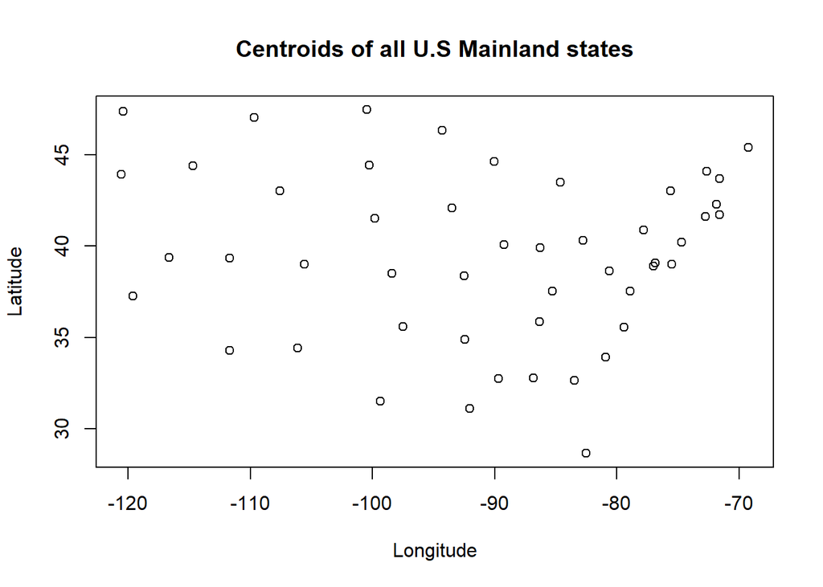

```r
plot(coordsStates,
             main="Centroids of all U.S Mainland states",
             xlab="Longitude",
             ylab="Latitude"
             )
```

Add the coordinates to the map

```r
trumpmap2016andCrime_noAorH$coordinates <- coordsStates
```

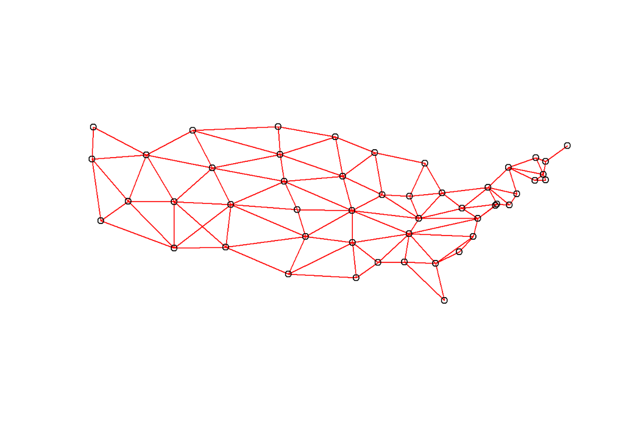

```r
States_nb <- poly2nb(trumpmap2016andCrime_noAorH, queen=T)

plot(States_nb, coordinates(coordsStates), col="red")
```

Then create the spatial weights matrix

```r
States.lw <- nb2listw(States_nb, style="C")

head(States.lw$neighbours)
```

```
## [[1]]
## [1]  9 10 24 43
##
## [[2]]
## [1]  4  5 28 31 45
##
## [[3]]
## [1] 17 24 25 37 43 44
##
## [[4]]
## [1]  2 28 38
##
## [[5]]
## [1]  2 15 27 31 37 45 51
##
## [[6]]
## [1] 21 32 33 40
```

An additional neighbours list is created here for later use in the 2016 hate crime statistics because there is missing data for Wyoming

```r
trumpmap2016andCrime_noAorH_noNA <-  trumpmap2016andCrime_noAorH[!is.na(trumpmap2016andCrime_noAorH$incident2016per100k), ]

States_noNA_nb <- poly2nb(trumpmap2016andCrime_noAorH_noNA, queen=T)
States_no_na.lw <- nb2listw(States_noNA_nb, style="C")
```

Mapping the percentage of Trump votes.

```r
#interactive map
tmap_mode("view")
```

```
## tmap mode set to interactive viewing
```

```r
tm_shape(trumpmap2016andCrime_noAorH) +
  tm_polygons("percenttrump",
              alpha = 1,
              palette = "Reds",
              style="cont",
              title="Percentage of Trump Votes 2016")+
  tm_layout(
    legend.title.size = 0.1,
    legend.text.size = 0.8
  )
```

[interactive chart not shown]

```r
#MAP ELECTION TRUMP VOTE %
tmap_mode("plot")
```

```
## tmap mode set to plotting
```

```r
electiontrumpvote <- tm_shape(trumpmap2016andCrime_noAorH) +
                    tm_polygons("percenttrump",
              palette = "Reds",
              style="cont",
              title="Trump Votes % 2016")+
  tm_layout(
    panel.show = TRUE,
    panel.labels = "Percentage of votes for Trump in the 2016 election",
    legend.title.size = 1,
    legend.text.size = 0.8,
    legend.height = 2)
tmap_save(tm=electiontrumpvote, filename = "electiontrumpvotemap.png")
```

```
## Map saved to C:\Users\tho84231\OneDrive - Mott MacDonald\Personal\Masters work\GIS\COURSEWORK\CourseworkFinal\electiontrumpvotemap.png
```

```
## Resolution: 2883.493 by 1529.395 pixels
```

```
## Size: 9.611644 by 5.097983 inches (300 dpi)
```

Mapping all 5 years of crime stats and exporting to picture.

```r
tmap_mode("plot")
```

```
## tmap mode set to plotting
```

```r
breaks2 <- c(0,1,2,4,10,20,30,40)


hatecrimeincident2014 <-tm_shape(trumpmap2016andCrime_noAorH) +
  tm_polygons("incident2014per100k",
              palette = "PuBuGn",
              style="fixed",
              breaks=breaks2,
              title="Hate crime incidents per 100,000")+
  tm_layout(
    panel.show = TRUE,
    panel.labels = "Hate crime incidents per 100,000 for 2014",
    legend.show = FALSE,
    legend.title.size = 0.7,
    legend.text.size = 0.7,
    legend.height = 2)

tmap_save(tm=hatecrimeincident2014, filename = "hatecrimeincident2014.png")
```

```
## Map saved to C:\Users\tho84231\OneDrive - Mott MacDonald\Personal\Masters work\GIS\COURSEWORK\CourseworkFinal\hatecrimeincident2014.png
```

```
## Resolution: 2883.493 by 1529.395 pixels
```

```
## Size: 9.611644 by 5.097983 inches (300 dpi)
```

```r
hatecrimeincident2015 <- tm_shape(trumpmap2016andCrime_noAorH) +
  tm_polygons("incident2015per100k",
              palette = "PuBuGn",
              style="fixed",
              breaks=breaks2,
              title="Hate crime incidents per 100,000")+
  tm_layout(
    panel.show = TRUE,
    panel.labels = "Hate crime incidents per 100,000 for 2015",
    legend.show = FALSE,
    legend.title.size = 0.7,
    legend.text.size = 0.7,
    legend.height = 2)

tmap_save(tm=hatecrimeincident2015, filename = "hatecrimeincident2015.png")
```

```
## Map saved to C:\Users\tho84231\OneDrive - Mott MacDonald\Personal\Masters work\GIS\COURSEWORK\CourseworkFinal\hatecrimeincident2015.png
```

```
## Resolution: 2883.493 by 1529.395 pixels
```

```
## Size: 9.611644 by 5.097983 inches (300 dpi)
```

```r
hatecrimeincident2016 <- tm_shape(trumpmap2016andCrime_noAorH) +
  tm_polygons("incident2016per100k",
              palette = "PuBuGn",
              style="fixed",
              breaks=breaks2,
              title="Hate crime incidents per 100,000")+
  tm_layout(
    panel.show = TRUE,
    panel.labels = "Hate crime incidents per 100,000 for 2016",
    legend.show = FALSE,
    legend.title.size = 0.7,
    legend.text.size = 0.7,
    legend.height = 2)

tmap_save(tm=hatecrimeincident2016, filename = "hatecrimeincident2016.png")
```

```
## Map saved to C:\Users\tho84231\OneDrive - Mott MacDonald\Personal\Masters work\GIS\COURSEWORK\CourseworkFinal\hatecrimeincident2016.png
```

```
## Resolution: 2883.493 by 1529.395 pixels
```

```
## Size: 9.611644 by 5.097983 inches (300 dpi)
```

```r
hatecrimeincident2017 <- tm_shape(trumpmap2016andCrime_noAorH) +
  tm_polygons("incident2017per100k",
              palette = "PuBuGn",
              style="fixed",
              breaks=breaks2,
              title="Hate crime incidents per 100,000")+
  tm_layout(
    panel.show = TRUE,
    panel.labels = "Hate crime incidents per 100,000 for 2017",
    legend.show = FALSE,
    legend.title.size = 0.7,
    legend.text.size = 0.7,
    legend.height = 2)

tmap_save(tm=hatecrimeincident2017, filename = "hatecrimeincident2017.png")
```

```
## Map saved to C:\Users\tho84231\OneDrive - Mott MacDonald\Personal\Masters work\GIS\COURSEWORK\CourseworkFinal\hatecrimeincident2017.png
```

```
## Resolution: 2883.493 by 1529.395 pixels
```

```
## Size: 9.611644 by 5.097983 inches (300 dpi)
```

```r
hatecrimeincident2018 <- tm_shape(trumpmap2016andCrime_noAorH) +
  tm_polygons("incident2018per100k",
              palette = "PuBuGn",
              style="fixed",
              breaks=breaks2,
              title="Hate crime incidents per 100,000")+
  tm_layout(
    panel.show = TRUE,
    panel.labels = "Hate crime incidents per 100,000 for 2018",
    legend.outside = TRUE,
    legend.text.size = 1,
    legend.height = 80)

tmap_save(tm=hatecrimeincident2018, filename = "hatecrimeincident2018.png")
```

```
## Map saved to C:\Users\tho84231\OneDrive - Mott MacDonald\Personal\Masters work\GIS\COURSEWORK\CourseworkFinal\hatecrimeincident2018.png
```

```
## Resolution: 2883.493 by 1529.395 pixels
```

```
## Size: 9.611644 by 5.097983 inches (300 dpi)
```

**Global Spatial Autocorrelation Moran’s I**

```r
MI_Global_DensityVOTES <- moran.test(trumpmap2016andCrime_noAorH$percenttrump  ,States.lw)

MI_Global_DensityVOTES
```

```
##
##  Moran I test under randomisation
##
## data:  trumpmap2016andCrime_noAorH$percenttrump
## weights: States.lw
##
## Moran I statistic standard deviate = 5.1909, p-value = 1.046e-07
## alternative hypothesis: greater
## sample estimates:
## Moran I statistic       Expectation          Variance
##       0.412234449      -0.020000000       0.006933556
```

```r
#2014

MI_Global_Density2014 <- moran.test(trumpmap2016andCrime_noAorH$incident2014per100k  ,States.lw)

MI_Global_Density2014
```

```
##
##  Moran I test under randomisation
##
## data:  trumpmap2016andCrime_noAorH$incident2014per100k
## weights: States.lw
##
## Moran I statistic standard deviate = 0.27466, p-value = 0.3918
## alternative hypothesis: greater
## sample estimates:
## Moran I statistic       Expectation          Variance
##       0.001621363      -0.020000000       0.006196764
```

```r
#2015

MI_Global_Density2015 <- moran.test(trumpmap2016andCrime_noAorH$incident2015per100k  ,States.lw)

MI_Global_Density2015
```

```
##
##  Moran I test under randomisation
##
## data:  trumpmap2016andCrime_noAorH$incident2015per100k
## weights: States.lw
##
## Moran I statistic standard deviate = 0.79162, p-value = 0.2143
## alternative hypothesis: greater
## sample estimates:
## Moran I statistic       Expectation          Variance
##        0.04386814       -0.02000000        0.00650928
```

```r
#2016
MI_Global_Density2016 <- moran.test(trumpmap2016andCrime_noAorH_noNA$incident2016per100k  ,States_no_na.lw)

MI_Global_Density2016
```

```
##
##  Moran I test under randomisation
##
## data:  trumpmap2016andCrime_noAorH_noNA$incident2016per100k
## weights: States_no_na.lw
##
## Moran I statistic standard deviate = 0.38555, p-value = 0.3499
## alternative hypothesis: greater
## sample estimates:
## Moran I statistic       Expectation          Variance
##       0.004655725      -0.020408163       0.004225984
```

```r
#2017

MI_Global_Density2017 <- moran.test(trumpmap2016andCrime_noAorH$incident2017per100k  ,States.lw)

MI_Global_Density2017
```

```
##
##  Moran I test under randomisation
##
## data:  trumpmap2016andCrime_noAorH$incident2017per100k
## weights: States.lw
##
## Moran I statistic standard deviate = 0.18277, p-value = 0.4275
## alternative hypothesis: greater
## sample estimates:
## Moran I statistic       Expectation          Variance
##      -0.010020537      -0.020000000       0.002981315
```

```r
#2018

MI_Global_Density2018 <- moran.test(trumpmap2016andCrime_noAorH$incident2018per100k  ,States.lw)

MI_Global_Density2018
```

```
##
##  Moran I test under randomisation
##
## data:  trumpmap2016andCrime_noAorH$incident2018per100k
## weights: States.lw
##
## Moran I statistic standard deviate = 0.22192, p-value = 0.4122
## alternative hypothesis: greater
## sample estimates:
## Moran I statistic       Expectation          Variance
##      -0.009339369      -0.020000000       0.002307683
```

**Global Spatial Autocorrelation Getis Ord General G**

Next is the Global Getis Ord General G test.

```r
#votes
Getis_Votes_Global_Density <- globalG.test(trumpmap2016andCrime_noAorH$percenttrump  ,States.lw)
Getis_Votes_Global_Density
```

```
##
##  Getis-Ord global G statistic
##
## data:  trumpmap2016andCrime_noAorH$percenttrump
## weights: States.lw
##
## standard deviate = 2.1699, p-value = 0.01501
## alternative hypothesis: greater
## sample estimates:
## Global G statistic        Expectation           Variance
##       2.141500e-02       2.000000e-02       4.252539e-07
```

```r
#2014
Getis_2014_Global_Density <- globalG.test(trumpmap2016andCrime_noAorH$incident2014per100k  ,States.lw)
Getis_2014_Global_Density
```

```
##
##  Getis-Ord global G statistic
##
## data:  trumpmap2016andCrime_noAorH$incident2014per100k
## weights: States.lw
##
## standard deviate = -0.58232, p-value = 0.7198
## alternative hypothesis: greater
## sample estimates:
## Global G statistic        Expectation           Variance
##       1.871030e-02       2.000000e-02       4.905243e-06
```

```r
#2015
Getis_2015_Global_Density <- globalG.test(trumpmap2016andCrime_noAorH$incident2015per100k  ,States.lw)
Getis_2015_Global_Density
```

```
##
##  Getis-Ord global G statistic
##
## data:  trumpmap2016andCrime_noAorH$incident2015per100k
## weights: States.lw
##
## standard deviate = -0.44481, p-value = 0.6718
## alternative hypothesis: greater
## sample estimates:
## Global G statistic        Expectation           Variance
##       1.917675e-02       2.000000e-02       3.425449e-06
```

```r
#2016
Getis_2016_Global_Density <- globalG.test(trumpmap2016andCrime_noAorH_noNA$incident2016per100k  ,States_no_na.lw)
Getis_2016_Global_Density
```

```
##
##  Getis-Ord global G statistic
##
## data:  trumpmap2016andCrime_noAorH_noNA$incident2016per100k
## weights: States_no_na.lw
##
## standard deviate = -0.68977, p-value = 0.7548
## alternative hypothesis: greater
## sample estimates:
## Global G statistic        Expectation           Variance
##       1.872248e-02       2.040816e-02       5.972368e-06
```

```r
#2017
Getis_2017_Global_Density <- globalG.test(trumpmap2016andCrime_noAorH$incident2017per100k  ,States.lw)
Getis_2017_Global_Density
```

```
##
##  Getis-Ord global G statistic
##
## data:  trumpmap2016andCrime_noAorH$incident2017per100k
## weights: States.lw
##
## standard deviate = -0.77766, p-value = 0.7816
## alternative hypothesis: greater
## sample estimates:
## Global G statistic        Expectation           Variance
##       0.0173142704       0.0200000000       0.0000119274
```

```r
#2018
Getis_2018_Global_Density <- globalG.test(trumpmap2016andCrime_noAorH$incident2018per100k  ,States.lw)
Getis_2018_Global_Density
```

```
##
##  Getis-Ord global G statistic
##
## data:  trumpmap2016andCrime_noAorH$incident2018per100k
## weights: States.lw
##
## standard deviate = -1.0177, p-value = 0.8456
## alternative hypothesis: greater
## sample estimates:
## Global G statistic        Expectation           Variance
##       1.613935e-02       2.000000e-02       1.439043e-05
```

**Local Spatial Autocorrelation Moran’s I**

Next is the local moran’s i calculcation to calculate a i score for each state and compare it to the whole and the accompanying maps.

```r
breaks1<-c(-1000,-2.58,-1.96,-1.65,1.65,1.96,2.58,1000)

MoranColours<- rev(brewer.pal(8, "Spectral"))

#morans I for votes

MI_State_Local_Density_votes <- localmoran(trumpmap2016andCrime_noAorH$percenttrump  ,States.lw)

trumpmap2016andCrime_noAorH$localvoteiscore <- MI_State_Local_Density_votes[,1]
trumpmap2016andCrime_noAorH$localvotezscore <- MI_State_Local_Density_votes[,4]


LocalM_votes <- tm_shape(trumpmap2016andCrime_noAorH) +
  tm_polygons("localvotezscore",
              style="fixed",
              breaks=breaks1,
              palette=MoranColours,
              midpoint=NA,
              title="Local Moran's i
z score per state")+

  tm_layout(
    panel.show = TRUE,
    panel.labels = "Local Moran's I for votes for Trump 2016",
    legend.title.size = 1,
    legend.text.size = 0.8,
    legend.height = 2)

tmap_save(tm=LocalM_votes, "LocalM_votes.png")
```

```
## Map saved to C:\Users\tho84231\OneDrive - Mott MacDonald\Personal\Masters work\GIS\COURSEWORK\CourseworkFinal\LocalM_votes.png
```

```
## Resolution: 2883.493 by 1529.395 pixels
```

```
## Size: 9.611644 by 5.097983 inches (300 dpi)
```

Next are the Local Moran’s i for all the hate crime statistics and the accompanying maps

```r
#morans I for hate crimes 2014

MI_State_Local_Density_2014 <- localmoran(trumpmap2016andCrime_noAorH$incident2014per100k  ,States.lw)

trumpmap2016andCrime_noAorH$local2014iscore <- MI_State_Local_Density_2014[,1]
trumpmap2016andCrime_noAorH$local2014zscore <- MI_State_Local_Density_2014[,4]


LocalM_2014 <- tm_shape(trumpmap2016andCrime_noAorH) +
  tm_polygons("local2014zscore",
              style="fixed",
              breaks=breaks1,
              palette=MoranColours,
              midpoint=NA,
              title="Local Moran's i:
z score per state")+

  tm_layout(
    legend.show = FALSE,
    panel.show = TRUE,
    panel.labels = "Local Moran's I for hate crimes 2014",
    legend.title.size = 1,
    legend.text.size = 0.8,
    legend.height = 2)

tmap_save(tm=LocalM_2014, "LocalM_2014.png")
```

```
## Map saved to C:\Users\tho84231\OneDrive - Mott MacDonald\Personal\Masters work\GIS\COURSEWORK\CourseworkFinal\LocalM_2014.png
```

```
## Resolution: 2883.493 by 1529.395 pixels
```

```
## Size: 9.611644 by 5.097983 inches (300 dpi)
```

```r
#morans I for hate crimes 2015

MI_State_Local_Density_2015 <- localmoran(trumpmap2016andCrime_noAorH$incident2015per100k  ,States.lw)

trumpmap2016andCrime_noAorH$local2015iscore <- MI_State_Local_Density_2015[,1]
trumpmap2016andCrime_noAorH$local2015zscore <- MI_State_Local_Density_2015[,4]


LocalM_2015 <- tm_shape(trumpmap2016andCrime_noAorH) +
  tm_polygons("local2015zscore",
              style="fixed",
              breaks=breaks1,
              palette=MoranColours,
              midpoint=NA,
              title="Local Moran's i:
z score per state")+

  tm_layout(
    legend.show = FALSE,
    panel.show = TRUE,
    panel.labels = "Local Moran's I for hate crimes 2015",
    legend.title.size = 1,
    legend.text.size = 0.8,
    legend.height = 2)

tmap_save(tm=LocalM_2015, "LocalM_2015.png")
```

```
## Map saved to C:\Users\tho84231\OneDrive - Mott MacDonald\Personal\Masters work\GIS\COURSEWORK\CourseworkFinal\LocalM_2015.png
```

```
## Resolution: 2883.493 by 1529.395 pixels
```

```
## Size: 9.611644 by 5.097983 inches (300 dpi)
```

```r
#morans I for hate crimes 2016

MI_State_Local_Density_2016 <- localmoran(trumpmap2016andCrime_noAorH_noNA$incident2016per100k  ,States_no_na.lw)

trumpmap2016andCrime_noAorH_noNA$local2016iscore <- MI_State_Local_Density_2016[,1]
trumpmap2016andCrime_noAorH_noNA$local2016zscore <- MI_State_Local_Density_2016[,4]


LocalM_2016 <- tm_shape(trumpmap2016andCrime_noAorH_noNA) +
  tm_polygons("local2016zscore",
              style="fixed",
              breaks=breaks1,
              palette=MoranColours,
              midpoint=NA,
              title="Local Moran's i:
z score per state")+

  tm_layout(
    legend.show = FALSE,
    panel.show = TRUE,
    panel.labels = "Local Moran's I for hate crimes 2016",
    legend.title.size = 1,
    legend.text.size = 0.8,
    legend.height = 2)

tmap_save(tm=LocalM_2016, "LocalM_2016.png")
```

```
## Map saved to C:\Users\tho84231\OneDrive - Mott MacDonald\Personal\Masters work\GIS\COURSEWORK\CourseworkFinal\LocalM_2016.png
```

```
## Resolution: 2883.493 by 1529.395 pixels
```

```
## Size: 9.611644 by 5.097983 inches (300 dpi)
```

```r
#morans I for hate crimes 2017

MI_State_Local_Density_2017 <- localmoran(trumpmap2016andCrime_noAorH$incident2017per100k  ,States.lw)

trumpmap2016andCrime_noAorH$local2017iscore <- MI_State_Local_Density_2017[,1]
trumpmap2016andCrime_noAorH$local2017zscore <- MI_State_Local_Density_2017[,4]


LocalM_2017 <- tm_shape(trumpmap2016andCrime_noAorH) +
  tm_polygons("local2017zscore",
              style="fixed",
              breaks=breaks1,
              palette=MoranColours,
              midpoint=NA,
              title="Local Moran's i:
z score per state")+

  tm_layout(
    legend.show = FALSE,
    panel.show = TRUE,
    panel.labels = "Local Moran's I for hate crimes 2017",
    legend.title.size = 1,
    legend.text.size = 0.8,
    legend.height = 2)

tmap_save(tm=LocalM_2017, "LocalM_2017.png")
```

```
## Map saved to C:\Users\tho84231\OneDrive - Mott MacDonald\Personal\Masters work\GIS\COURSEWORK\CourseworkFinal\LocalM_2017.png
```

```
## Resolution: 2883.493 by 1529.395 pixels
```

```
## Size: 9.611644 by 5.097983 inches (300 dpi)
```

```r
#morans I for hate crimes 2018

MI_State_Local_Density_2018 <- localmoran(trumpmap2016andCrime_noAorH$incident2018per100k  ,States.lw)

trumpmap2016andCrime_noAorH$local2018iscore <- MI_State_Local_Density_2018[,1]
trumpmap2016andCrime_noAorH$local2018zscore <- MI_State_Local_Density_2018[,4]


LocalM_2018 <- tm_shape(trumpmap2016andCrime_noAorH) +
  tm_polygons("local2018zscore",
              style="fixed",
              breaks=breaks1,
              palette=MoranColours,
              midpoint=NA,
              title="Local Moran's i:
z score per state")+

  tm_layout(
    legend.show = TRUE,
    legend.outside = TRUE,
    panel.show = TRUE,
    panel.labels = "Local Moran's I for hate crimes 2018",
    legend.title.size = 1.7,
    legend.text.size = 1.3
    )

tmap_save(tm=LocalM_2018, "LocalM_2018.png")
```

```
## Map saved to C:\Users\tho84231\OneDrive - Mott MacDonald\Personal\Masters work\GIS\COURSEWORK\CourseworkFinal\LocalM_2018.png
```

```
## Resolution: 2883.493 by 1529.395 pixels
```

```
## Size: 9.611644 by 5.097983 inches (300 dpi)
```

```r
LocalM_2018_nolegend <- tm_shape(trumpmap2016andCrime_noAorH) +
  tm_polygons("local2018zscore",
              style="fixed",
              breaks=breaks1,
              palette=MoranColours,
              midpoint=NA,
              title="Local Moran's i:
z score per state")+

  tm_layout(
    legend.show = FALSE,
    legend.outside = TRUE,
    panel.show = TRUE,
    panel.labels = "Local Moran's I for hate crimes 2018",
    legend.title.size = 1.7,
    legend.text.size = 1.3
  )

tmap_save(tm=LocalM_2018_nolegend, "LocalM_2018_nolegend.png")
```

```
## Map saved to C:\Users\tho84231\OneDrive - Mott MacDonald\Personal\Masters work\GIS\COURSEWORK\CourseworkFinal\LocalM_2018_nolegend.png
```

```
## Resolution: 2883.493 by 1529.395 pixels
```

```
## Size: 9.611644 by 5.097983 inches (300 dpi)
```

And finally the local Getis Ord Gi* for votes and hate crimes. With the accompanying maps

First with the analysis and an interactive map

```r
#Gi Local Analysis for votes

Gi_States_Local_votes <- localG(trumpmap2016andCrime_noAorH$percenttrump, States.lw)
trumpmap2016andCrime_noAorH$votes_LocalGiz <- Gi_States_Local_votes

GIColours<- rev(brewer.pal(8, "RdYlBu"))



tmap_mode("view")
```

```
## tmap mode set to interactive viewing
```

```r
tm_shape(trumpmap2016andCrime_noAorH)+
tm_polygons("votes_LocalGiz",
            style="fixed",
            breaks = breaks1,
            palette=GIColours,
            midpoint=NA,
            title="Gi* statistic")
```

[interactive chart not shown]

And then all the plots produced for votes and hate crimes.

```r
GI_Local_votes <- tm_shape(trumpmap2016andCrime_noAorH) +
  tm_polygons("votes_LocalGiz",
              style="fixed",
              breaks = breaks1,
              palette=GIColours,
              midpoint=NA,
              title="Gi* statistic")+

  tm_layout(
    legend.show = TRUE,
    panel.show = TRUE,
    panel.labels = "Getis Ord Gi* Hot and Cold Spots for votes for Trump 2016",
    legend.title.size = 1,
    legend.text.size = 0.8,
    legend.height = 2)

tmap_save(tm=GI_Local_votes, "GI_Local_votes.png")
```

```
## Map saved to C:\Users\tho84231\OneDrive - Mott MacDonald\Personal\Masters work\GIS\COURSEWORK\CourseworkFinal\GI_Local_votes.png
```

```
## Resolution: 2883.493 by 1529.395 pixels
```

```
## Size: 9.611644 by 5.097983 inches (300 dpi)
```

```r
#Gi Local Analysis for 2014

Gi_States_Local_2014 <- localG(trumpmap2016andCrime_noAorH$incident2014per100k, States.lw)
trumpmap2016andCrime_noAorH$LocalGiz2014 <- Gi_States_Local_2014

GI_Local_2014 <- tm_shape(trumpmap2016andCrime_noAorH) +
  tm_polygons("LocalGiz2014",
              style="fixed",
              breaks = breaks1,
              palette=GIColours,
              midpoint=NA,
              title="Gi* statistic")+

  tm_layout(
    legend.show = FALSE,
    panel.show = TRUE,
    panel.labels = "Getis Ord Gi* Hot and Cold Spots for 2014 hate crimes",
    legend.title.size = 1,
    legend.text.size = 0.8,
    legend.height = 2)

tmap_save(tm=GI_Local_2014, "GI_Local_2014.png")
```

```
## Map saved to C:\Users\tho84231\OneDrive - Mott MacDonald\Personal\Masters work\GIS\COURSEWORK\CourseworkFinal\GI_Local_2014.png
```

```
## Resolution: 2883.493 by 1529.395 pixels
```

```
## Size: 9.611644 by 5.097983 inches (300 dpi)
```

```r
#Gi Local Analysis for 2015

Gi_States_Local_2015 <- localG(trumpmap2016andCrime_noAorH$incident2015per100k, States.lw)
trumpmap2016andCrime_noAorH$LocalGiz2015 <- Gi_States_Local_2015

GI_Local_2015 <- tm_shape(trumpmap2016andCrime_noAorH) +
  tm_polygons("LocalGiz2015",
              style="fixed",
              breaks = breaks1,
              palette=GIColours,
              midpoint=NA,
              title="Gi* statistic")+

  tm_layout(
    legend.show = FALSE,
    panel.show = TRUE,
    panel.labels = "Getis Ord Gi* Hot and Cold Spots for 2015 hate crimes",
    legend.title.size = 1,
    legend.text.size = 0.8,
    legend.height = 2)

tmap_save(tm=GI_Local_2015, "GI_Local_2015.png")
```

```
## Map saved to C:\Users\tho84231\OneDrive - Mott MacDonald\Personal\Masters work\GIS\COURSEWORK\CourseworkFinal\GI_Local_2015.png
```

```
## Resolution: 2883.493 by 1529.395 pixels
```

```
## Size: 9.611644 by 5.097983 inches (300 dpi)
```

```r
#Gi Local Analysis for 2016

Gi_States_Local_2016 <- localG(trumpmap2016andCrime_noAorH_noNA$incident2016per100k  ,States_no_na.lw)
trumpmap2016andCrime_noAorH_noNA$LocalGiz2016 <- Gi_States_Local_2016

GI_Local_2016 <- tm_shape(trumpmap2016andCrime_noAorH_noNA) +
  tm_polygons("LocalGiz2016",
              style="fixed",
              breaks = breaks1,
              palette=GIColours,
              midpoint=NA,
              title="Gi* statistic")+

  tm_layout(
    legend.show = FALSE,
    panel.show = TRUE,
    panel.labels = "Getis Ord Gi* Hot and Cold Spots for 2016 hate crimes",
    legend.title.size = 1,
    legend.text.size = 0.8,
    legend.height = 2)

tmap_save(tm=GI_Local_2016, "GI_Local_2016.png")
```

```
## Map saved to C:\Users\tho84231\OneDrive - Mott MacDonald\Personal\Masters work\GIS\COURSEWORK\CourseworkFinal\GI_Local_2016.png
```

```
## Resolution: 2883.493 by 1529.395 pixels
```

```
## Size: 9.611644 by 5.097983 inches (300 dpi)
```

```r
#Gi Local Analysis for 2017

Gi_States_Local_2017 <- localG(trumpmap2016andCrime_noAorH$incident2017per100k, States.lw)
trumpmap2016andCrime_noAorH$LocalGiz2017 <- Gi_States_Local_2017

GI_Local_2017 <- tm_shape(trumpmap2016andCrime_noAorH) +
  tm_polygons("LocalGiz2017",
              style="fixed",
              breaks = breaks1,
              palette=GIColours,
              midpoint=NA,
              title="Gi* statistic")+

  tm_layout(
    legend.show = FALSE,
    panel.show = TRUE,
    panel.labels = "Getis Ord Gi* Hot and Cold Spots for 2017 hate crimes",
    legend.title.size = 1,
    legend.text.size = 0.8,
    legend.height = 2)

tmap_save(tm=GI_Local_2017, "GI_Local_2017.png")
```

```
## Map saved to C:\Users\tho84231\OneDrive - Mott MacDonald\Personal\Masters work\GIS\COURSEWORK\CourseworkFinal\GI_Local_2017.png
```

```
## Resolution: 2883.493 by 1529.395 pixels
```

```
## Size: 9.611644 by 5.097983 inches (300 dpi)
```

```r
#Gi Local Analysis for 2018

Gi_States_Local_2018 <- localG(trumpmap2016andCrime_noAorH$incident2018per100k, States.lw)

trumpmap2016andCrime_noAorH$LocalGiz2018 <- Gi_States_Local_2018

tmap_mode("view")
```

```
## tmap mode set to interactive viewing
```

```r
tm_shape(trumpmap2016andCrime_noAorH) +
  tm_polygons("LocalGiz2018",
              style="fixed",
              breaks = breaks1,
              palette=GIColours,
              midpoint=NA,
              title="Gi* statistic")
```

[interactive chart not shown]

```r
GI_Local_2018 <- tm_shape(trumpmap2016andCrime_noAorH) +
  tm_polygons("LocalGiz2018",
              style="fixed",
              breaks = breaks1,
              palette=GIColours,
              midpoint=NA,
              title="Gi* statistic")+

  tm_layout(
    legend.show = TRUE,
    legend.outside = TRUE,
    panel.show = TRUE,
    panel.labels = "Getis Ord Gi* Hot and Cold Spots for 2018 hate crimes",
    legend.title.size = 1.7,
    legend.text.size = 1.3)

tmap_save(tm=GI_Local_2018, "GI_Local_2018.png")
```

```
## Map saved to C:\Users\tho84231\OneDrive - Mott MacDonald\Personal\Masters work\GIS\COURSEWORK\CourseworkFinal\GI_Local_2018.png
```

```
## Resolution: 2883.493 by 1529.395 pixels
```

```
## Size: 9.611644 by 5.097983 inches (300 dpi)
```

```r
#2018 without legend
GI_Local_2018_nolegend <- tm_shape(trumpmap2016andCrime_noAorH) +
  tm_polygons("LocalGiz2018",
              style="fixed",
              breaks = breaks1,
              palette=GIColours,
              midpoint=NA,
              title="Gi* statistic")+

  tm_layout(
    legend.show = FALSE,
    legend.outside = TRUE,
    panel.show = TRUE,
    panel.labels = "Getis Ord Gi* Hot and Cold Spots for 2018 hate crimes",
    legend.title.size = 1.7,
    legend.text.size = 1.3)

tmap_save(tm=GI_Local_2018_nolegend, "GI_Local_2018_nolegend.png")
```

```
## Map saved to C:\Users\tho84231\OneDrive - Mott MacDonald\Personal\Masters work\GIS\COURSEWORK\CourseworkFinal\GI_Local_2018_nolegend.png
```

```
## Resolution: 2883.493 by 1529.395 pixels
```

```
## Size: 9.611644 by 5.097983 inches (300 dpi)
```